# Midterm

Author

6345

Published

March 5, 2024

## Assignment overview

To begin, download the following from the Midterm section of the web book:

- Quarto notebook for the midterm:`midterm.qmd`
- 3 data sets: `data_1.csv`, `data_2.csv`, `data_3.csv`
- 1 data dictionary: `data_1_dictionary.docx`

Your midterm is due Wednesday at 8:00 PM. Good luck, you got this!

## Setup

### Handle conflicts

```r
options(conflicts.policy = "depends.ok")
devtools::source_url("https://github.com/jjcurtin/lab_support/blob/main/fun_ml.R?raw=true")
```

```
ℹ SHA-1 hash of file is "77e91675366f10788c6bcb59fa1cfc9ee0c75281"
```

```r
tidymodels_conflictRules()
conflictRules("Matrix", mask.ok = c("expand", "pack", "unpack"))
```

### Load required packages

```r
library(tidyverse)
library(tidymodels)
library(xfun, include.only = "cache_rds")
library(cowplot, include.only = c("plot_grid", "theme_half_open"))
library(discrim, exclude = "smoothness")
```

### Source function scripts (John’s or your own)

```r
devtools::source_url("https://github.com/jjcurtin/lab_support/blob/main/fun_plots.R?raw=true")
```

```
ℹ SHA-1 hash of file is "def6ce26ed7b2493931fde811adff9287ee8d874"
```

```r
devtools::source_url("https://github.com/jjcurtin/lab_support/blob/main/fun_eda.R?raw=true")
```

```
ℹ SHA-1 hash of file is "c045eee2655a18dc85e715b78182f176327358a7"
```

### Specify other global settings

```r
theme_set(theme_classic())
options(tibble.width = Inf, dplyr.print_max=Inf)
rerun_setting <- TRUE
```

### Paths

```r
path_data <- "homework/unit_07"
```

## Part 1: EDA

In this portion of the assignment, you will do some basic cleaning and modeling EDA of `data_1.csv`, which contains adoption data from Petfinder.com. The primary outcome variable is `AdoptionTime`, which is the number of weeks the pet was in the shelter before being adopted. You will perform EDA on this data set as described below:

### Load data 1

Read in `data_1.csv` using best practices

```r
data_all_1 <- read_csv(here::here(path_data, "data_1.csv"),
                     col_types = cols()) |>
  glimpse()
```

```
Rows: 2,900
Columns: 12
$ AdoptionTime <dbl> 12, 0, 7, 14, 9, 10, 11, 9, 14, 9, 8, 8, 8, 7, 11, 44, 6,…
$ AnimalType   <dbl> 1, 2, 2, 1, 2, 2, 1, 1, 1, 2, 2, 1, 1, 2, 2, 2, 1, 2, 1, …
$ Gender       <dbl> 1, 2, 2, 1, 2, 1, 2, 1, 2, 1, 1, 2, 1, 2, 1, 1, 2, 2, 1, …
$ Age          <dbl> 52, 22, 39, 69, 51, 50, 39, 37, 50, 57, 52, 34, 44, 40, 4…
$ Friendliness <dbl> 5, 6, 5, 4, 6, 5, 3, 3, 3, 4, 5, 5, 5, 4, 3, 3, 3, 2, 7, …
$ Color        <chr> "Brown Tan", "Brown Tan", "Gray", "Black", "Brown Tan", "…
$ Pattern      <chr> "Spotted", "Spotted", "Spotted", "Spotted", "Silver tippe…
$ FurLength    <chr> "Medium", "Medium", "Medium", "Medium", "Medium", "Medium…
$ NumberPhotos <dbl> 1, 2, 2, 1, 1, 1, 1, 1, 1, 1, 1, 1, 1, 1, 1, 0, 1, 0, 1, …
$ AdoptionFee  <dbl> 528, 730, 312, 522, 482, 470, 582, 506, 608, 442, 440, 42…
$ ExpectedSize <chr> "medium", "medium", "medium", "large", "large", "large", …
$ Vaccinated   <chr> "Y", "Y", "Y", "Y", "Y", "Y", "Y", "Y", "Y", "Y", "Y", "Y…
```

### Variable classes and tidy names

Read the data dictionary and examine the classes of variables. Reclass any variables that are read in as the wrong class and tidy variable names

```r
# Clean Column Names
data_all_1 <- data_all_1  |> janitor::clean_names("snake")

# Clean Observations
data_all_1 <- data_all_1 |>
  mutate(across(where(is.character), tidy_responses)) |> glimpse()
```

```
Rows: 2,900
Columns: 12
$ adoption_time <dbl> 12, 0, 7, 14, 9, 10, 11, 9, 14, 9, 8, 8, 8, 7, 11, 44, 6…
$ animal_type   <dbl> 1, 2, 2, 1, 2, 2, 1, 1, 1, 2, 2, 1, 1, 2, 2, 2, 1, 2, 1,…
$ gender        <dbl> 1, 2, 2, 1, 2, 1, 2, 1, 2, 1, 1, 2, 1, 2, 1, 1, 2, 2, 1,…
$ age           <dbl> 52, 22, 39, 69, 51, 50, 39, 37, 50, 57, 52, 34, 44, 40, …
$ friendliness  <dbl> 5, 6, 5, 4, 6, 5, 3, 3, 3, 4, 5, 5, 5, 4, 3, 3, 3, 2, 7,…
$ color         <fct> brown_tan, brown_tan, gray, black, brown_tan, gray, gray…
$ pattern       <fct> spotted, spotted, spotted, spotted, silver_tipped, silve…
$ fur_length    <fct> medium, medium, medium, medium, medium, medium, medium, …
$ number_photos <dbl> 1, 2, 2, 1, 1, 1, 1, 1, 1, 1, 1, 1, 1, 1, 1, 0, 1, 0, 1,…
$ adoption_fee  <dbl> 528, 730, 312, 522, 482, 470, 582, 506, 608, 442, 440, 4…
$ expected_size <fct> medium, medium, medium, large, large, large, large, larg…
$ vaccinated    <fct> y, y, y, y, y, y, y, y, y, y, y, y, y, y, y, y, y, y, y,…
```

```r
# Change NA in Pattern to be No Category
data_all_1 <- data_all_1 %>% mutate(pattern = fct_expand(pattern, "no_category"),
                  pattern = replace_na(pattern, "no_category"))

# Reclass Variables
data_all_1 <- data_all_1 |>
    mutate(across(where(is.character), factor)) |>
    mutate(color = fct_relevel(color, c("black", "brown_tan", "gray", "orange", "white_cream")),
           pattern = fct_relevel(pattern, c("exotic_spots", "facial_markings","golden_mix", "marbled",
                                            "multicolored", "patchy", "rusty", "seal_point", "semi_spotted",
                                            "silver_tipped", "solid_color", "spotted", "striped",
                                            "striped_tail", "tabby", "tuxedo", "two_toned",
                                            "white_belly","white_paws", "no_category")),
           fur_length = fct_relevel(fur_length, c("long", "medium", "short", "not_specified")),
           expected_size = fct_relevel(expected_size, c("small", "medium", "large", "extra_chunky")),
           vaccinated = factor(vaccinated, levels = c("n", "y")),
           animal_type = factor(animal_type, levels = 1:2),
           gender = factor(gender, levels = 1:2),
           friendliness = factor(friendliness, levels = 1:10))

# Set Outliers to NA
data_all_1$age[data_all_1$age > 1000 | data_all_1$age < 0] <- NA
```

### Skim data

Use the appropriate technique to skim the full data. Type your answers to questions about your observations below the code chunk

```r
data_all_1 |>
  skim_some()
```

Data summary

| Name | data_all_1 |
| --- | --- |
| Number of rows | 2900 |
| Number of columns | 12 |
| _______________________ |  |
| Column type frequency: |  |
| factor | 8 |
| numeric | 4 |
| ________________________ |  |
| Group variables | None |

**Variable type: factor**

| skim_variable | n_missing | complete_rate | ordered | n_unique | top_counts |
| --- | --- | --- | --- | --- | --- |
| animal_type | 0 | 1 | FALSE | 2 | 2: 1459, 1: 1441 |
| gender | 0 | 1 | FALSE | 2 | 2: 1514, 1: 1386 |
| friendliness | 0 | 1 | FALSE | 10 | 6: 812, 5: 727, 4: 600, 3: 348 |
| color | 0 | 1 | FALSE | 5 | bro: 1468, gra: 1158, bla: 203, whi: 70 |
| pattern | 0 | 1 | FALSE | 20 | no_: 1077, spo: 443, str: 267, two: 194 |
| fur_length | 0 | 1 | FALSE | 4 | med: 2595, not: 153, sho: 128, lon: 24 |
| expected_size | 0 | 1 | FALSE | 4 | lar: 1519, med: 1301, ext: 64, sma: 16 |
| vaccinated | 0 | 1 | FALSE | 2 | y: 2704, n: 196 |

**Variable type: numeric**

| skim_variable | n_missing | complete_rate | p0 | p100 |
| --- | --- | --- | --- | --- |
| adoption_time | 0 | 1 | 0 | 66 |
| age | 2 | 1 | 1 | 205 |
| number_photos | 1 | 1 | 0 | 3 |
| adoption_fee | 1 | 1 | 0 | 1488 |

#### **1.1) What do you notice about missing data? How would you plan to handle variables with missing values? Will you handle missingness the same for all variables - explain why or why not?**

*There were missing values for pattern, but looking at the dictionary NA referred to the pattern being unable to categorize. I recoded NA to be no_category. There is also one missing value for number of photos and adoption fee, since these are numeric predictors I can use step_impute_median when making recipes.*

#### **1.2) What do you notice about the range of your numeric values?**

*Age has a minimum of -2 and a maximum of 1100. These are both impossible values as a pet can not be in the negative ages and 1100 months is about 92 years which is also impossible.*

### Categorical response levels

Print levels of each categorical variable. Tidy categorical variable levels. Convert all response levels to snake_case and check to make sure all levels were converted properly

```r
data_all_1 |> select(where(is.factor)) |> lapply(levels)
```

```
$animal_type
[1] "1" "2"

$gender
[1] "1" "2"

$friendliness
 [1] "1"  "2"  "3"  "4"  "5"  "6"  "7"  "8"  "9"  "10"

$color
[1] "black"       "brown_tan"   "gray"        "orange"      "white_cream"

$pattern
 [1] "exotic_spots"    "facial_markings" "golden_mix"      "marbled"
 [5] "multicolored"    "patchy"          "rusty"           "seal_point"
 [9] "semi_spotted"    "silver_tipped"   "solid_color"     "spotted"
[13] "striped"         "striped_tail"    "tabby"           "tuxedo"
[17] "two_toned"       "white_belly"     "white_paws"      "no_category"

$fur_length
[1] "long"          "medium"        "short"         "not_specified"

$expected_size
[1] "small"        "medium"       "large"        "extra_chunky"

$vaccinated
[1] "n" "y"
```

### Generate a Train/test split

Split the data into a single train and test set. Retain 3/4 of the data as training. Stratify on the outcome. Make sure this split can be reproduced

```r
set.seed(13)

splits_test1 <- data_all_1 |>
  initial_split(prop = 0.75, strata = "adoption_time")

data_trn1 <- splits_test1 |>
  analysis()

data_test1 <- splits_test1 |>
  assessment()
```

### Save cleaned files

Save cleaned train and test sets as .csv files and name them `data_1_train.csv` and `data_1_test.csv`.

```r
data_trn1 |>
  write_csv(here::here(path_data, "data_1_train.csv"))
data_test1 |>
  write_csv(here::here(path_data, "data_1_test.csv"))
```

### Read data

Load the cleaned training dataset (`data_1_train.csv`) and review it

```r
data_1_train <- read_csv(here::here(path_data, "data_1_train.csv"),
                     col_types = cols()) |>
                glimpse()
```

```
Rows: 2,173
Columns: 12
$ adoption_time <dbl> 0, 3, 2, 0, 1, 1, 2, 1, 2, 3, 3, 3, 3, 2, 2, 3, 3, 0, 1,…
$ animal_type   <dbl> 2, 1, 2, 2, 2, 2, 1, 2, 2, 1, 2, 1, 1, 2, 1, 1, 2, 2, 1,…
$ gender        <dbl> 2, 1, 1, 2, 2, 2, 1, 2, 2, 1, 2, 2, 1, 1, 2, 1, 1, 1, 2,…
$ age           <dbl> 22, 22, 21, 26, 30, 30, 17, 61, 23, 28, 28, 45, 35, 54, …
$ friendliness  <dbl> 6, 7, 7, 5, 6, 5, 5, 5, 6, 6, 6, 5, 7, 6, 6, 6, 6, 7, 6,…
$ color         <chr> "brown_tan", "brown_tan", "brown_tan", "brown_tan", "bro…
$ pattern       <chr> "spotted", "spotted", "spotted", "marbled", "marbled", "…
$ fur_length    <chr> "medium", "medium", "not_specified", "medium", "medium",…
$ number_photos <dbl> 2, 1, 3, 2, 2, 2, 2, 1, 2, 2, 2, 1, 3, 3, 3, 2, 2, 1, 2,…
$ adoption_fee  <dbl> 730, 525, 0, 264, 320, 264, 264, 539, 280, 308, 260, 475…
$ expected_size <chr> "medium", "medium", "medium", "medium", "medium", "mediu…
$ vaccinated    <chr> "y", "y", "y", "y", "y", "y", "y", "y", "y", "y", "y", "…
```

### Variable classes

Reclass any variables that are read in as the wrong class

```r
data_1_train <- data_1_train |>
    mutate(across(where(is.character), factor)) |>
    mutate(color = suppressWarnings(fct_relevel(color, c("black", "brown_tan", "gray", "orange", "white_cream"))),
           pattern = fct_relevel(pattern, c("exotic_spots", "facial_markings","golden_mix", "marbled",
                                            "multicolored", "patchy", "rusty", "seal_point", "semi_spotted",
                                            "silver_tipped", "solid_color", "spotted", "striped",
                                            "striped_tail", "tabby", "tuxedo", "two_toned",
                                            "white_belly","white_paws", "no_category")),
           fur_length = fct_relevel(fur_length, c("long", "medium", "short", "not_specified")),
           expected_size = fct_relevel(expected_size, c("small", "medium", "large", "extra_chunky")),
           vaccinated = factor(vaccinated, levels = c("n", "y")),
           animal_type = factor(animal_type, levels = 1:2),
           gender = factor(gender, levels = 1:2),
           friendliness = factor(friendliness, levels = 1:10))
```

### Variable distributions

Examine univariate distributions of all variables

- Generate box violin plots for all numeric variables.
- Generate bar plots for all categorical variables

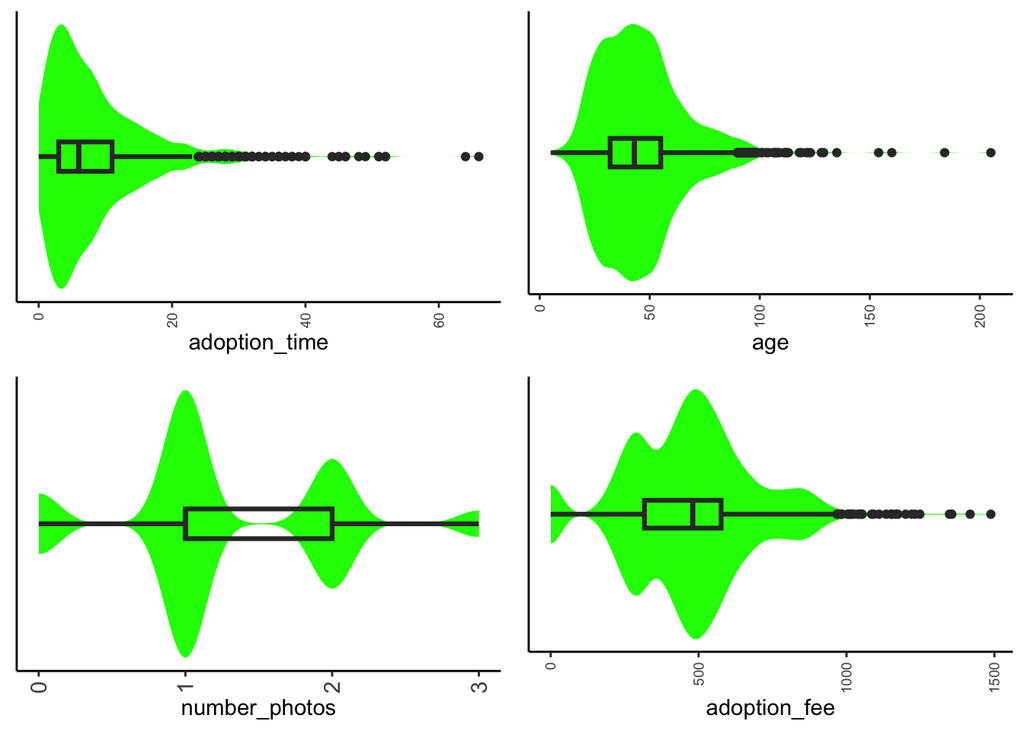

```r
# Box Violin Plots
data_1_train |>
  select(where(is.numeric)) |>
  names() |>
  map(\(name) plot_box_violin(df = data_1_train, x = name)) |>
  plot_grid(plotlist = _, ncol = 2)
```

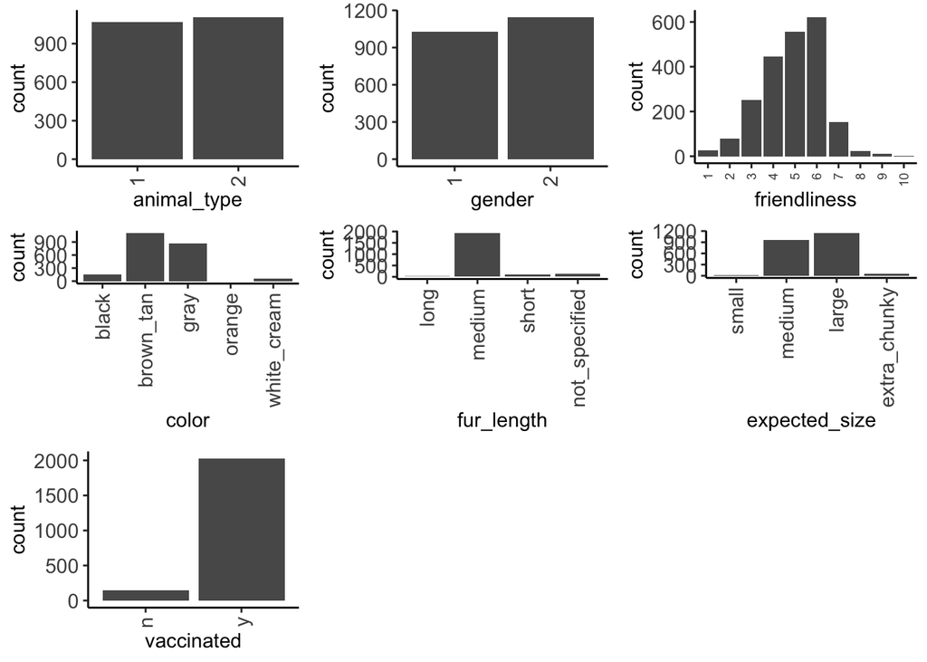

```r
# Bar Plots
data_1_train |>
  select(where(is.factor), -pattern) |>
  names() |>
  map(\(name) plot_bar(df = data_1_train, x = name)) |>
  plot_grid(plotlist = _, ncol = 3)
```

Examine bivariate relationships between all predictors and the outcome `AdoptionTime`

- Numeric predictors: generate scatter plots and a correlation plot
- Categorical predictors: generate grouped box violin plots

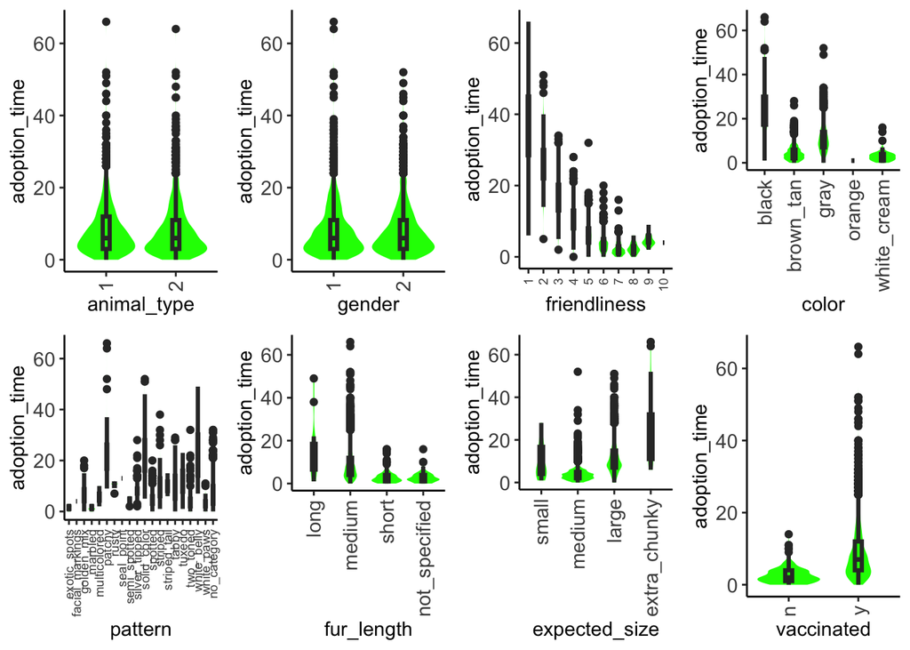

```r
# Grouped Box Violin Plots
data_1_train |>
  select(where(is.factor)) |>
  names() |>
  map(~ plot_grouped_box_violin(df = data_1_train, x = ., y = "adoption_time")) |>
  plot_grid(plotlist = _, ncol = 4)
```

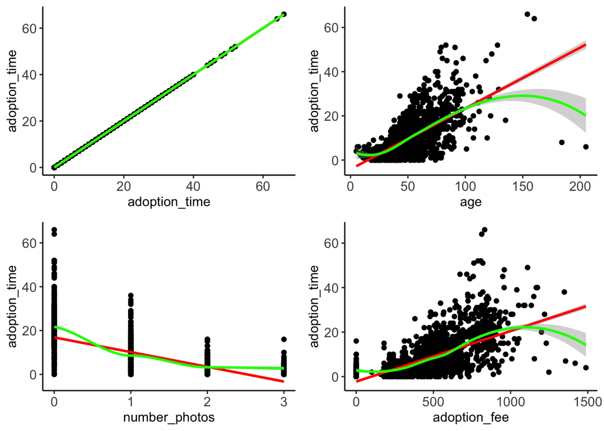

```r
# Scatter Plots
data_1_train |>
  select(where(is.numeric)) |>
  names() |>
  map(~ plot_scatter(df = data_1_train, x = ., y = "adoption_time")) |>
  plot_grid(plotlist = _, ncol = 2)
```

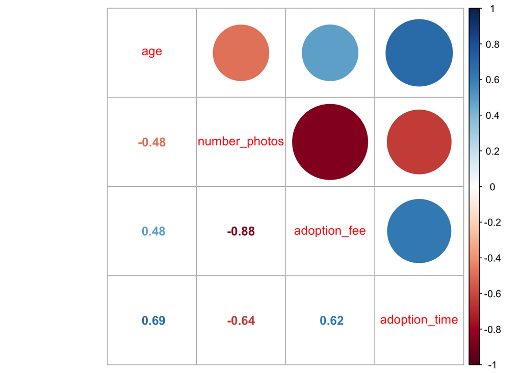

```r
# Correlation Plot
data_1_train |>
  select(where(is.numeric)) |>
  relocate(adoption_time, .after = last_col()) |>
  cor(use = "pairwise.complete.obs") |>
  corrplot::corrplot.mixed()
```

After reviewing distribution plots, answer the following questions:

#### **1.4) Which variables appear to contain outlier values? What options could you consider to handle these outliers?**

*Age has an outlier of 1100, I would consider replacing this since it is an impossible value. I would do this by setting them to NA so I can use step_impute_median() later.*

#### **1.5) Which categorical variables contain levels that you might consider collapsing? Why?**

*Pattern has a few levels that contain less than 10 observations so I might consider collapsing them. Collapsing these levels can make the variable easier to interpret, especially since the collapsed categories share similar characteristics and are very specific.*

### Potential interactions

You notice that extra chunky animals tend to take longer to get adopted (despite being extra cute). You wonder if this is less of an issue when animals are adopted at younger ages (and adopters may not realize how large their animals will become). Use tools from the book (or resources you find on the internet) to create visualizations to investigate this potential interaction effect between `ExpectedSize` and `Age` of pet on time it takes for shelter animals to be adopted (`AdoptionTime`).

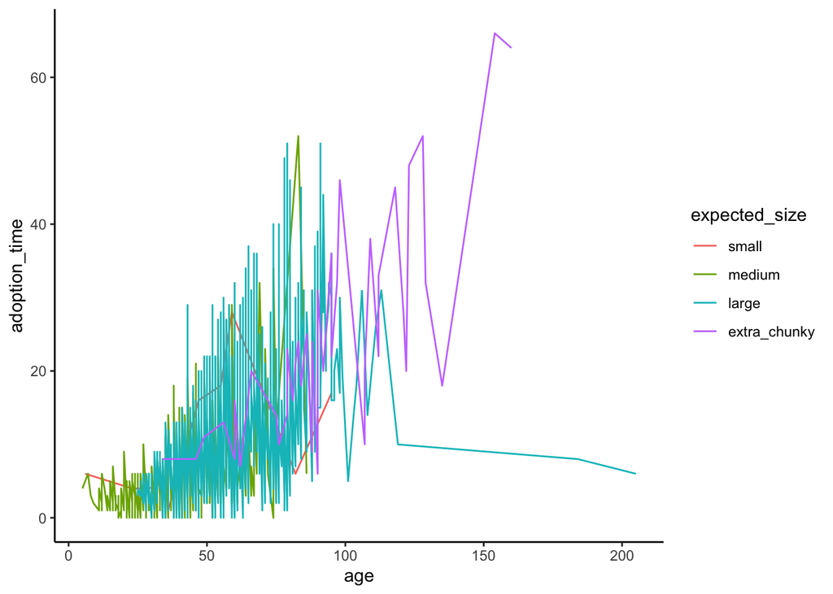

```r
# Line Graph showing Interaction
ggplot(aes(x=age, y=adoption_time, color = expected_size), data = data_1_train) +
  geom_line()
```

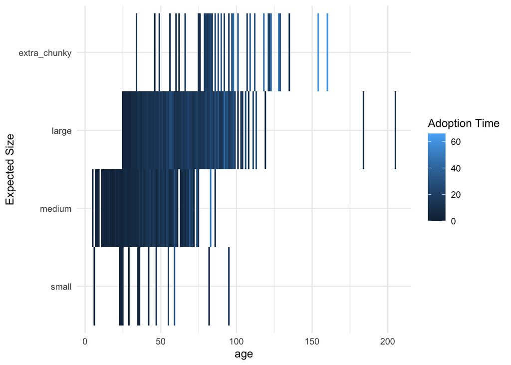

```r
# Heat Map showing Interaction
ggplot(data_1_train, aes(x = age, y = expected_size, fill = adoption_time)) +
  geom_tile() +
  labs(x = "age", y = "Expected Size", fill = "Adoption Time") +
  theme_minimal()
```

### Recipe for linear model

Write a recipe to fit a linear model to predict `AdoptionTime` from all predictors. Informed from your EDA above, be sure to include the following steps in your recipe: - Step to address missing data - Step to collapse at least one categorical predictor - Step to normalize numeric predictors - Appropriate steps for categorical predictors - Include the interaction between `ExpectedSize` and `Age` (regardless of what your EDA above revealed)

```r
rec_1 <-
  recipe(adoption_time ~ ., data = data_1_train) |>
  step_impute_median(number_photos, adoption_fee, age) |>
  step_normalize(all_numeric_predictors()) |>
  step_other(pattern, threshold = 10, other = "other") |>
  step_interact(terms = ~ expected_size:age) |>
  step_dummy(all_nominal_predictors())
```

### Training feature matrix

prep recipe

```r
rec_prep_1 <- rec_1 |>
  prep(training = data_1_train)
```

bake recipe to get feature set

```r
feat_trn_1 <- rec_prep_1 |>
  bake(new_data = data_1_train)

feat_test_1 <- rec_prep_1 |>
  bake(data_test1)
```

## Part 2: Model fitting

In this section, we will use cleaned data from `data_2.csv` which contains data about various breast cancer tumors and classifies them as benign or malignant. You will use bootstrapped resampling to choose between a logistic regression vs QDA model to predict if a breast cancer tumor is benign vs malignant using all available variables.

### Set up parallel processing

```r
cl <- parallel::makePSOCKcluster(parallel::detectCores(logical = FALSE))
doParallel::registerDoParallel(cl)
```

Load the cleaned `data_2.csv` file and confirm variables are properly classed

```r
data_2 <- read_csv(here::here(path_data, "data_2.csv"),
                     col_types = cols()) |>
                glimpse()
```

```
Rows: 569
Columns: 31
$ diagnosis               <chr> "malignant", "malignant", "malignant", "malign…
$ radius_mean             <dbl> 17.990, 20.570, 19.690, 11.420, 20.290, 12.450…
$ texture_mean            <dbl> 10.38, 17.77, 21.25, 20.38, 14.34, 15.70, 19.9…
$ perimeter_mean          <dbl> 122.80, 132.90, 130.00, 77.58, 135.10, 82.57, …
$ area_mean               <dbl> 1001.0, 1326.0, 1203.0, 386.1, 1297.0, 477.1, …
$ smoothness_mean         <dbl> 0.11840, 0.08474, 0.10960, 0.14250, 0.10030, 0…
$ compactness_mean        <dbl> 0.27760, 0.07864, 0.15990, 0.28390, 0.13280, 0…
$ concavity_mean          <dbl> 0.30010, 0.08690, 0.19740, 0.24140, 0.19800, 0…
$ concave_points_mean     <dbl> 0.14710, 0.07017, 0.12790, 0.10520, 0.10430, 0…
$ symmetry_mean           <dbl> 0.2419, 0.1812, 0.2069, 0.2597, 0.1809, 0.2087…
$ fractal_dimension_mean  <dbl> 0.07871, 0.05667, 0.05999, 0.09744, 0.05883, 0…
$ radius_se               <dbl> 1.0950, 0.5435, 0.7456, 0.4956, 0.7572, 0.3345…
$ texture_se              <dbl> 0.9053, 0.7339, 0.7869, 1.1560, 0.7813, 0.8902…
```

[output cut: 18 more lines]

```r
data_2$diagnosis <- factor(data_2$diagnosis)
glimpse(data_2)
```

```
Rows: 569
Columns: 31
$ diagnosis               <fct> malignant, malignant, malignant, malignant, ma…
$ radius_mean             <dbl> 17.990, 20.570, 19.690, 11.420, 20.290, 12.450…
$ texture_mean            <dbl> 10.38, 17.77, 21.25, 20.38, 14.34, 15.70, 19.9…
$ perimeter_mean          <dbl> 122.80, 132.90, 130.00, 77.58, 135.10, 82.57, …
$ area_mean               <dbl> 1001.0, 1326.0, 1203.0, 386.1, 1297.0, 477.1, …
$ smoothness_mean         <dbl> 0.11840, 0.08474, 0.10960, 0.14250, 0.10030, 0…
$ compactness_mean        <dbl> 0.27760, 0.07864, 0.15990, 0.28390, 0.13280, 0…
$ concavity_mean          <dbl> 0.30010, 0.08690, 0.19740, 0.24140, 0.19800, 0…
$ concave_points_mean     <dbl> 0.14710, 0.07017, 0.12790, 0.10520, 0.10430, 0…
$ symmetry_mean           <dbl> 0.2419, 0.1812, 0.2069, 0.2597, 0.1809, 0.2087…
$ fractal_dimension_mean  <dbl> 0.07871, 0.05667, 0.05999, 0.09744, 0.05883, 0…
$ radius_se               <dbl> 1.0950, 0.5435, 0.7456, 0.4956, 0.7572, 0.3345…
$ texture_se              <dbl> 0.9053, 0.7339, 0.7869, 1.1560, 0.7813, 0.8902…
```

[output cut: 18 more lines]

Split your data into 100 bootstrap samples stratified on `diagnosis`. Make sure these splits can be reproduced

```r
splits_boot <- data_2 |>
  bootstraps(times = 100, strata = "diagnosis")
```

Create a simple recipe that can be used for both a logistic regression and qda statistical algorithms. Create features from the numeric predictors in their raw, untransformed state

```r
rec_2 <- recipe(diagnosis ~ ., data = data_2)
```

### Logistic regression

prep recipe

```r
rec_prep_2 <- rec_2 |>
  prep(training = data_2)
```

bake recipe to get feature set

```r
feat_trn_2 <- rec_prep_2 |>
  bake(data_2)
```

Fit a logistic regression classifier using the recipe you created and your bootstrap splits. Use accuracy as your metric.

- Output a table of model performance across all 100 bootstraps
- Plot a histogram of model performance across all 100 bootstraps
- Output the average accuracy of this logistic regression configuration

```r
# Fit Model
fits_linear <- cache_rds(
  expr = {
  logistic_reg() |>
  set_engine("glm") |>
  fit_resamples(preprocessor = rec_2,
                resamples = splits_boot,
                metrics = metric_set(accuracy))
  },
  dir = "cache/",
  file = "unit7linear",
  rerun = rerun_setting)

# Table
metrics_fits_linear<- collect_metrics(fits_linear, summarize = FALSE)
metrics_fits_linear |> print_kbl()
```

| id | .metric | .estimator | .estimate | .config |
| --- | --- | --- | --- | --- |
| Bootstrap001 | accuracy | binary | 0.94 | Preprocessor1_Model1 |
| Bootstrap002 | accuracy | binary | 0.96 | Preprocessor1_Model1 |
| Bootstrap003 | accuracy | binary | 0.93 | Preprocessor1_Model1 |
| Bootstrap004 | accuracy | binary | 0.93 | Preprocessor1_Model1 |
| Bootstrap005 | accuracy | binary | 0.95 | Preprocessor1_Model1 |
| Bootstrap006 | accuracy | binary | 0.95 | Preprocessor1_Model1 |
| Bootstrap007 | accuracy | binary | 0.95 | Preprocessor1_Model1 |
| Bootstrap008 | accuracy | binary | 0.92 | Preprocessor1_Model1 |
| Bootstrap009 | accuracy | binary | 0.94 | Preprocessor1_Model1 |
| Bootstrap010 | accuracy | binary | 0.93 | Preprocessor1_Model1 |
| Bootstrap011 | accuracy | binary | 0.96 | Preprocessor1_Model1 |
| Bootstrap012 | accuracy | binary | 0.97 | Preprocessor1_Model1 |
| Bootstrap013 | accuracy | binary | 0.94 | Preprocessor1_Model1 |
| Bootstrap014 | accuracy | binary | 0.94 | Preprocessor1_Model1 |
| Bootstrap015 | accuracy | binary | 0.96 | Preprocessor1_Model1 |
| Bootstrap016 | accuracy | binary | 0.91 | Preprocessor1_Model1 |
| Bootstrap017 | accuracy | binary | 0.91 | Preprocessor1_Model1 |
| Bootstrap018 | accuracy | binary | 0.95 | Preprocessor1_Model1 |
| Bootstrap019 | accuracy | binary | 0.94 | Preprocessor1_Model1 |
| Bootstrap020 | accuracy | binary | 0.91 | Preprocessor1_Model1 |
| Bootstrap021 | accuracy | binary | 0.95 | Preprocessor1_Model1 |
| Bootstrap022 | accuracy | binary | 0.94 | Preprocessor1_Model1 |
| Bootstrap023 | accuracy | binary | 0.92 | Preprocessor1_Model1 |
| Bootstrap024 | accuracy | binary | 0.93 | Preprocessor1_Model1 |
| Bootstrap025 | accuracy | binary | 0.95 | Preprocessor1_Model1 |
| Bootstrap026 | accuracy | binary | 0.96 | Preprocessor1_Model1 |
| Bootstrap027 | accuracy | binary | 0.95 | Preprocessor1_Model1 |
| Bootstrap028 | accuracy | binary | 0.92 | Preprocessor1_Model1 |
| Bootstrap029 | accuracy | binary | 0.95 | Preprocessor1_Model1 |
| Bootstrap030 | accuracy | binary | 0.93 | Preprocessor1_Model1 |

[output cut: 70 more lines]

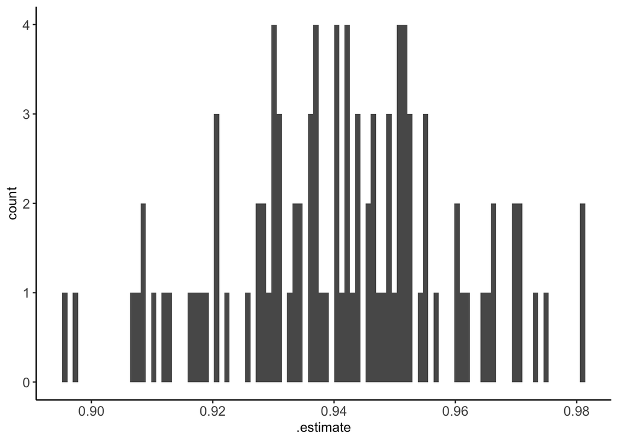

```r
# Histogram
metrics_fits_linear |> plot_hist(".estimate")
```

```r
# Average Accuracy
collect_metrics(fits_linear, summarize = TRUE) # 0.942
```

```
# A tibble: 1 × 6
  .metric  .estimator  mean     n std_err .config
  <chr>    <chr>      <dbl> <int>   <dbl> <chr>
1 accuracy binary     0.941   100 0.00182 Preprocessor1_Model1
```

### QDA

Fit an QDA using the RDA statistical algorithm (don’t forget to set the hyperparameter to their appropriate values to get a pure QDA) using the same recipe above and the same bootstrap splits. Again, use accuracy as your metric.

- Output a table of model performance across all 100 bootstraps
- Plot a histogram of model performance across all 100 bootstraps
- Output the average accuracy of this QDA configuration

```r
# Fit Model
fit_qda <- cache_rds(
  expr = {
  discrim_regularized(frac_common_cov = 0, frac_identity = 0) |>
  set_engine("klaR") |>
  fit_resamples(preprocessor = rec_2,
                resamples = splits_boot,
                metrics = metric_set(accuracy))
  },
  dir = "cache/",
  file = "unit7qda",
  rerun = rerun_setting)

# Table
metrics_fits_qda  <- collect_metrics(fit_qda, summarize = FALSE)
metrics_fits_qda |> print_kbl()
```

| id | .metric | .estimator | .estimate | .config |
| --- | --- | --- | --- | --- |
| Bootstrap001 | accuracy | binary | 0.96 | Preprocessor1_Model1 |
| Bootstrap002 | accuracy | binary | 0.96 | Preprocessor1_Model1 |
| Bootstrap003 | accuracy | binary | 0.94 | Preprocessor1_Model1 |
| Bootstrap004 | accuracy | binary | 0.95 | Preprocessor1_Model1 |
| Bootstrap005 | accuracy | binary | 0.97 | Preprocessor1_Model1 |
| Bootstrap006 | accuracy | binary | 0.96 | Preprocessor1_Model1 |
| Bootstrap007 | accuracy | binary | 0.95 | Preprocessor1_Model1 |
| Bootstrap008 | accuracy | binary | 0.97 | Preprocessor1_Model1 |
| Bootstrap009 | accuracy | binary | 0.97 | Preprocessor1_Model1 |
| Bootstrap010 | accuracy | binary | 0.92 | Preprocessor1_Model1 |
| Bootstrap011 | accuracy | binary | 0.95 | Preprocessor1_Model1 |
| Bootstrap012 | accuracy | binary | 0.96 | Preprocessor1_Model1 |
| Bootstrap013 | accuracy | binary | 0.95 | Preprocessor1_Model1 |
| Bootstrap014 | accuracy | binary | 0.95 | Preprocessor1_Model1 |
| Bootstrap015 | accuracy | binary | 0.95 | Preprocessor1_Model1 |
| Bootstrap016 | accuracy | binary | 0.93 | Preprocessor1_Model1 |
| Bootstrap017 | accuracy | binary | 0.94 | Preprocessor1_Model1 |
| Bootstrap018 | accuracy | binary | 0.95 | Preprocessor1_Model1 |
| Bootstrap019 | accuracy | binary | 0.95 | Preprocessor1_Model1 |
| Bootstrap020 | accuracy | binary | 0.96 | Preprocessor1_Model1 |
| Bootstrap021 | accuracy | binary | 0.96 | Preprocessor1_Model1 |
| Bootstrap022 | accuracy | binary | 0.97 | Preprocessor1_Model1 |
| Bootstrap023 | accuracy | binary | 0.94 | Preprocessor1_Model1 |
| Bootstrap024 | accuracy | binary | 0.93 | Preprocessor1_Model1 |
| Bootstrap025 | accuracy | binary | 0.94 | Preprocessor1_Model1 |
| Bootstrap026 | accuracy | binary | 0.96 | Preprocessor1_Model1 |
| Bootstrap027 | accuracy | binary | 0.96 | Preprocessor1_Model1 |
| Bootstrap028 | accuracy | binary | 0.92 | Preprocessor1_Model1 |
| Bootstrap029 | accuracy | binary | 0.98 | Preprocessor1_Model1 |
| Bootstrap030 | accuracy | binary | 0.93 | Preprocessor1_Model1 |

[output cut: 70 more lines]

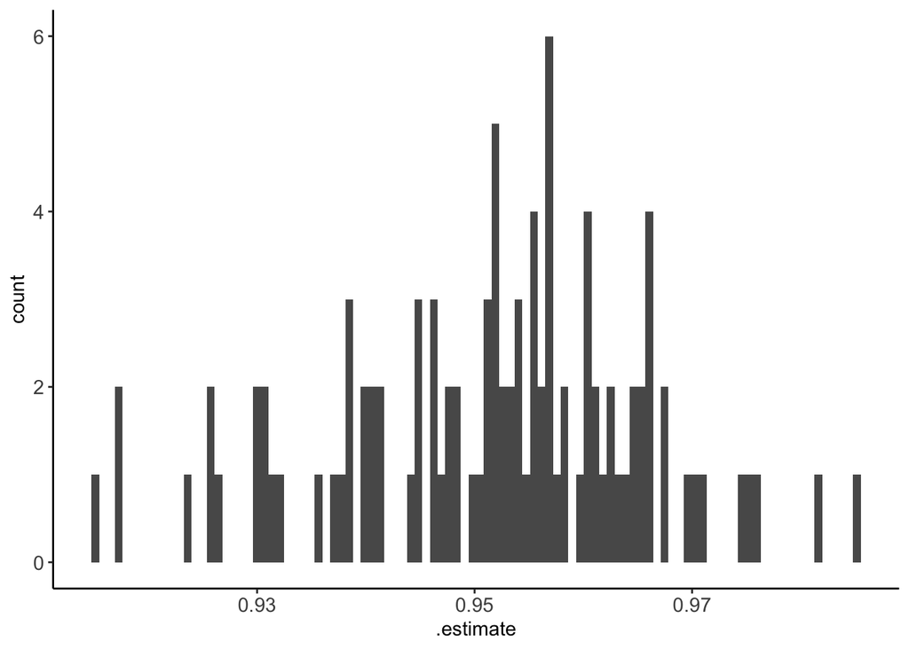

```r
# Histogram
metrics_fits_qda |> plot_hist(".estimate")
```

```r
# Average Accuracy
collect_metrics(fit_qda, summarize = TRUE) # 0.952
```

```
# A tibble: 1 × 6
  .metric  .estimator  mean     n std_err .config
  <chr>    <chr>      <dbl> <int>   <dbl> <chr>
1 accuracy binary     0.952   100 0.00141 Preprocessor1_Model1
```

#### **2.2) What does your best classifier being a logistic regression vs QDA suggest about the structure of your data?**

*My best classifier being a QDA might suggest that the data was not linear since QDA can handle non-linearity. Because QDA outperformed logistic regression, it might suggest that the decision boundary was not linear and needed a more flexible model.*

#### **2.3) Why use bootstrapped resampling to make this decision?**

*Bootstrapping resampling allows for a reliable estimate of well each model performs on average. It does this by averaging the performance metric across multiple samples obtained by bootstrapping resampling. In this case, we were more concerned about a precise selection metric rather than worrying about bias and bootstrapping is best for this scenario.*